# Plots for the the Freeze-thaw project

Ivan Calandra

2026-04-22 10:36:26 CEST

# 1 Goal of the script

The script plots all STA variables for the Freeze-thaw dataset.

```r
dir_in  <- "analysis/derived_data"
dir_plots <- "analysis/plots"
```

Input Rbin data file must be located in “./analysis/derived_data”.  
Plots will be saved in “./analysis/plots”.

The knit directory for this script is the project directory. This is important to specify the path for input and output.  
However, the HTML, MD and BIB files resulting from the rendering of this Rmd file will be located in the same folder as the Rmd file (i.e. “`./analysis/scripts`”).

# 2 Load packages

```r
library(doBy)
library(factoextra)
library(ggarrow)
library(ggh4x)
library(ggplot2)
library(ggrepel)
library(grateful)
library(knitr)
library(patchwork)
library(R.utils)
library(RColorBrewer)
library(rmarkdown)
library(tidyverse)
```

# 3 Read in STA data

```r
FT_file <- list.files(dir_in, pattern = ".*STA.*\\.Rbin$", full.names = TRUE)
FT <- loadObject(FT_file)
```

The following data file has been read: “analysis/derived_data/FT_STA_formatted-data.Rbin”

Below are its structure and first lines:

```r
str(FT)
```

```
'data.frame':   80 obs. of  42 variables:
 $ Specimen                : chr  "Scra11" "Scra11" "Scra11" "Scra11" ...
 $ Sediment                : chr  "Quincay" "Quincay" "Quincay" "Quincay" ...
 $ Cycles                  : num  600 600 600 600 0 0 0 0 330 330 ...
 $ State                   : Factor w/ 2 levels "before","after": 2 2 2 2 1 1 1 1 2 2 ...
 $ Location                : chr  "loc1" "loc2" "loc3" "loc4" ...
 $ Use                     : chr  "used" "used" "used" "unused" ...
 $ NMP                     : num  6.21 8.99 9.36 7.09 5.59 ...
 $ NMP_cat                 : Ord.factor w/ 3 levels "<10%"<"10-17%"<..: 1 1 1 1 1 1 1 1 2 2 ...
 $ Sq                      : num  510 599 627 536 461 ...
 $ Ssk                     : num  0.208 0.104 -1.349 0.307 0.364 ...
 $ Sku                     : num  3.61 4.28 16.22 3.5 3.44 ...
 $ Sp                      : num  2002 2280 4021 2237 1940 ...
 $ Sv                      : num  1895 2130 4888 1622 1193 ...
 $ Sz                      : num  3898 4410 8910 3859 3134 ...
```

[output cut: 30 more lines]

```r
head(FT)
```

```
  Specimen Sediment Cycles  State Location    Use      NMP NMP_cat       Sq
1   Scra11  Quincay    600  after     loc1   used 6.210140    <10% 510.3147
2   Scra11  Quincay    600  after     loc2   used 8.988605    <10% 599.4221
3   Scra11  Quincay    600  after     loc3   used 9.360195    <10% 626.8703
4   Scra11  Quincay    600  after     loc4 unused 7.087054    <10% 535.8293
5   Scra11  Quincay      0 before     loc1   used 5.585075    <10% 461.3625
6   Scra11  Quincay      0 before     loc2   used 7.824051    <10% 537.4528
         Ssk       Sku       Sp       Sv       Sz       Sa       Smr      Smc
1  0.2082995  3.611167 2002.269 1895.237 3897.506 395.2242 3.3585136 630.9984
2  0.1038576  4.277262 2280.247 2129.979 4410.227 444.2419 2.6425792 705.0265
3 -1.3491279 16.215072 4021.251 4888.391 8909.643 399.6521 0.1384577 594.0357
4  0.3066295  3.504882 2236.933 1622.238 3859.171 420.7068 1.9326553 670.0448
5  0.3644242  3.438282 1940.378 1193.170 3133.549 362.0558 3.1472606 568.2292
6 -0.3339857  4.060290 1796.531 2537.250 4333.781 412.1910 6.2930831 674.2111
        Sxp      Sal       Str      Std       Ssw       Sdq       Sdr
```

[output cut: 34 more lines]

# 4 Format STA data

## 4.1 Exclude NMP, and combine Specimen and Location in one column

```r
# Exclude NMP
FT <- select(FT, !NMP)  %>%

      # Combine Specimen and Location in one column
      # Necessary to connect points when plotting individual points
      mutate(SpecLoc = paste(Specimen, Location, sep = "-")) %>%

      # Combine Specimen and Use in one column
      # Necessary to connect points when plotting mean points
      mutate(SpecUse = paste(Specimen, Use, sep = "-"))
```

## 4.2 Create new datasets based on NMP_cat

```r
# Select all rows with NMP_cat ≤ 10%
FT_NMP10 <- filter(FT, NMP_cat == "<10%")

# Select all rows with NMP_cat ≤ 10% or 10-17%
FT_NMP17 <- filter(FT, NMP_cat %in% c("<10%", "10-17%"))
```

When considering only height maps with 10% NMP or less, 45 height maps are excluded and 35 are kept for further analysis.  
When considering only height maps with 17% NMP or less, 8 height maps are excluded and 72 are kept for further analysis.

## 4.3 Calculate the mean per specimen per cycle

```r
# Calculate means based on Specimen + Cycles + Use
# Sediment and SpecUse are listed as factor in order to keep these columns
# keep.names = TRUE is important for the matching on names in the plots
FT_NMP10_mean <- summaryBy(.~ Specimen + Sediment + Cycles + Use + SpecUse,
                           data = FT_NMP10, FUN = mean, keep.names = TRUE)
FT_NMP17_mean <- summaryBy(.~ Specimen + Sediment + Cycles + Use + SpecUse,
                           data = FT_NMP17, FUN = mean, keep.names = TRUE)
```

## 4.4 Add units to headers for plotting

This cannot be done before on `FT` because it create problems during the calculations of the means due to the column names with spaces and special characters (for units).  
Also, for `FT_NMP10` and `FT_NMP17`, a copy is created here because such column names are also problematic for the PCA (see below).

```r
# Get units from comment(FT)
table_units <- comment(FT) %>%
               data.frame(Parameter = names(.), Unit = ., row.names = NULL) %>%

               # Exclude NMP because it won't be plotted
               filter(Parameter != "NMP") %>%

               # Paste parameter name and unit together in a new column
               mutate(Param_unit = paste0(Parameter, " [", Unit, "]"))

# Remove > and < symbols
table_units$Param_unit <- gsub(">|<", "", table_units$Param_unit)

# Create copies of FT_NMP10 and FT_NMP17
FT_NMP10_units <- FT_NMP10
FT_NMP17_units <- FT_NMP17

# Adjust column names
colnames(FT_NMP10_units)[colnames(FT_NMP10_units) %in% table_units$Parameter] <- table_units$Param_unit
colnames(FT_NMP17_units)[colnames(FT_NMP17_units) %in% table_units$Parameter] <- table_units$Param_unit
colnames(FT_NMP10_mean)[colnames(FT_NMP10_mean)   %in% table_units$Parameter] <- table_units$Param_unit
colnames(FT_NMP17_mean)[colnames(FT_NMP17_mean)   %in% table_units$Parameter] <- table_units$Param_unit
```

These are the new column names for the plots:

```
Sq [nm]
Ssk [no unit]
Sku [no unit]
Sp [nm]
Sv [nm]
Sz [nm]
Sa [nm]
Smr [%]
Smc [nm]
Sxp [nm]
Sal [µm]
Str [no unit]
Std [°]
Ssw [µm]
Sdq [no unit]
Sdr [%]
Vm [µm³/µm²]
Vv [µm³/µm²]
Vmp [µm³/µm²]
Vmc [µm³/µm²]
Vvc [µm³/µm²]
Vvv [µm³/µm²]
First.direction [°]
Second.direction [°]
Third.direction [°]
Texture.isotropy [%]
Maximum.depth.of.furrows [nm]
Mean.depth.of.furrows [nm]
Mean.density.of.furrows [cm/cm2]
epLsar [no unit]
NewEplsar [no unit]
Asfc [no unit]
Smfc [µm²]
HAsfc9 [no unit]
```

# 5 Line plots of STA for height maps with <17% NMP

See section Line plots for height maps with <10% NMP for line plots for height maps with <10% NMP.

## 5.1 Create list to receive the plots

```r
p_line_NMP17 <- vector(mode = "list", length = nrow(table_units))
names(p_line_NMP17) <- table_units$Param_unit
```

## 5.2 Plots

```
$`Sq [nm]`
```

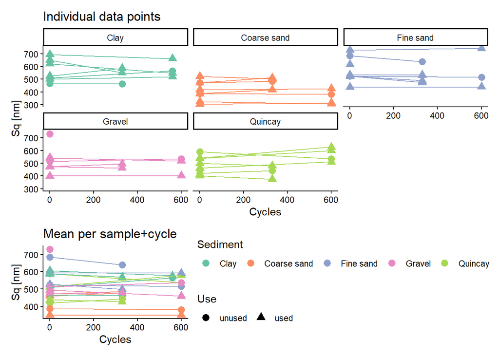

```
$`Ssk [no unit]`
```

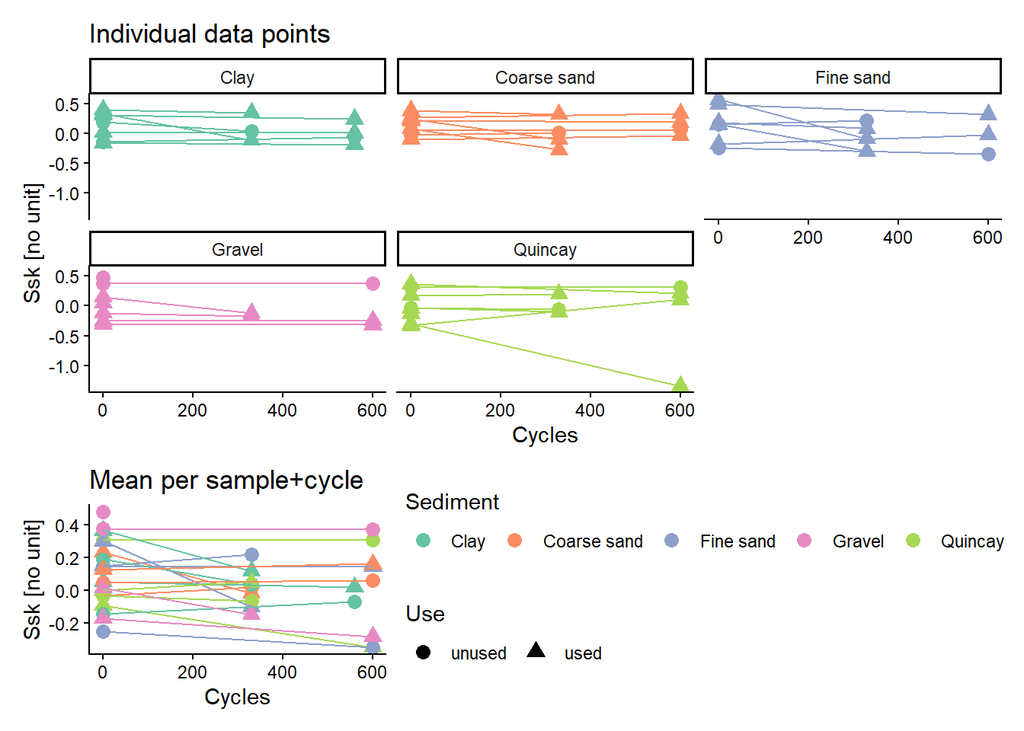

```
$`Sku [no unit]`
```

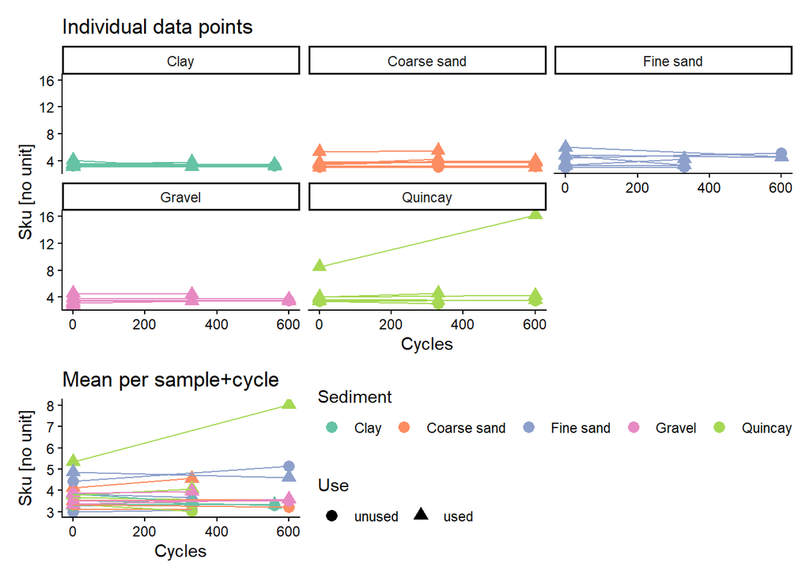

```
$`Sp [nm]`
```

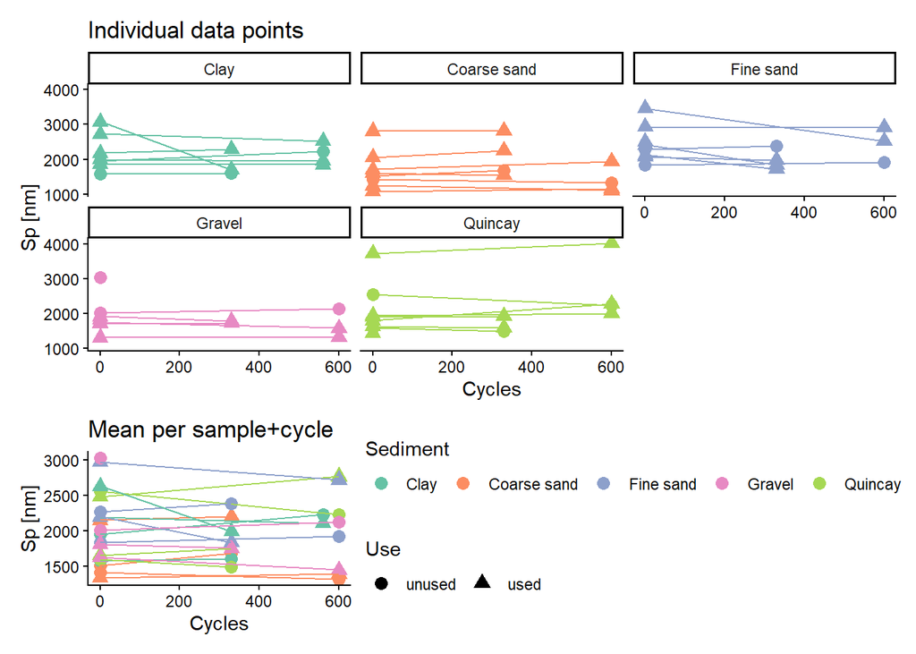

```
$`Sv [nm]`
```

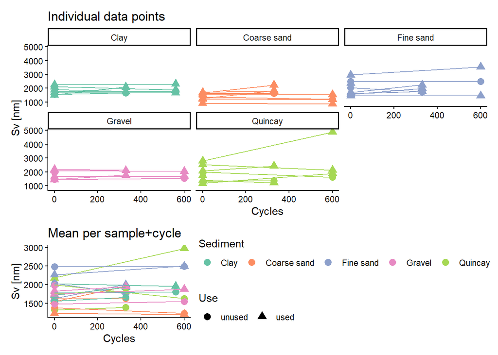

```
$`Sz [nm]`
```

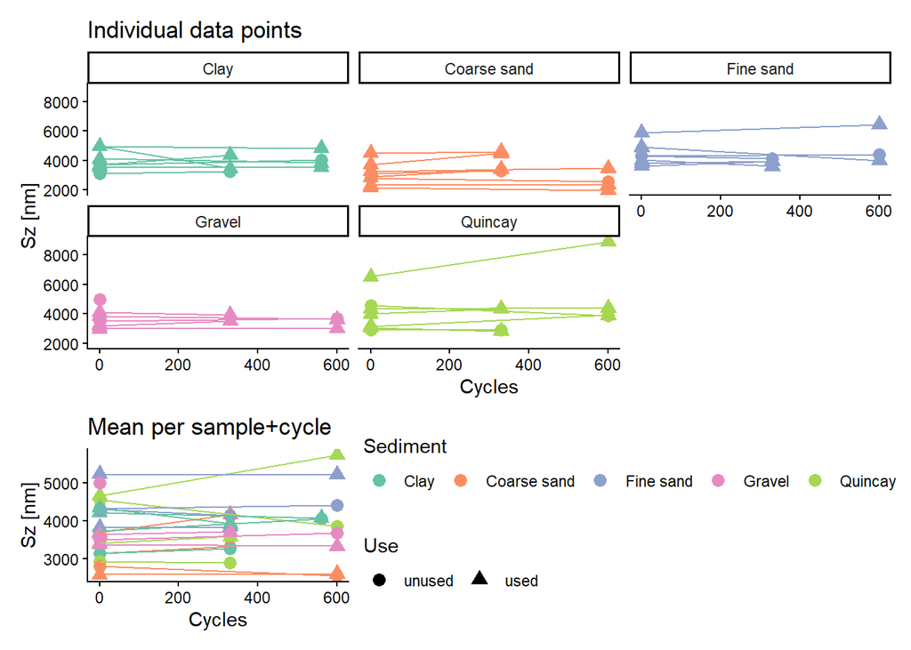

```
$`Sa [nm]`
```

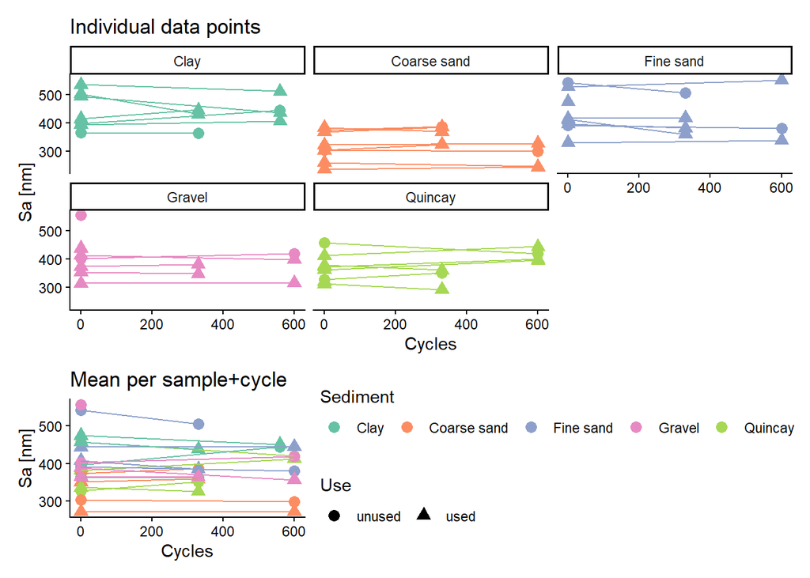

```
$`Smr [%]`
```

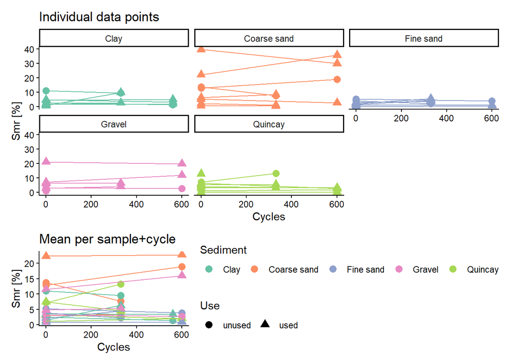

```
$`Smc [nm]`
```

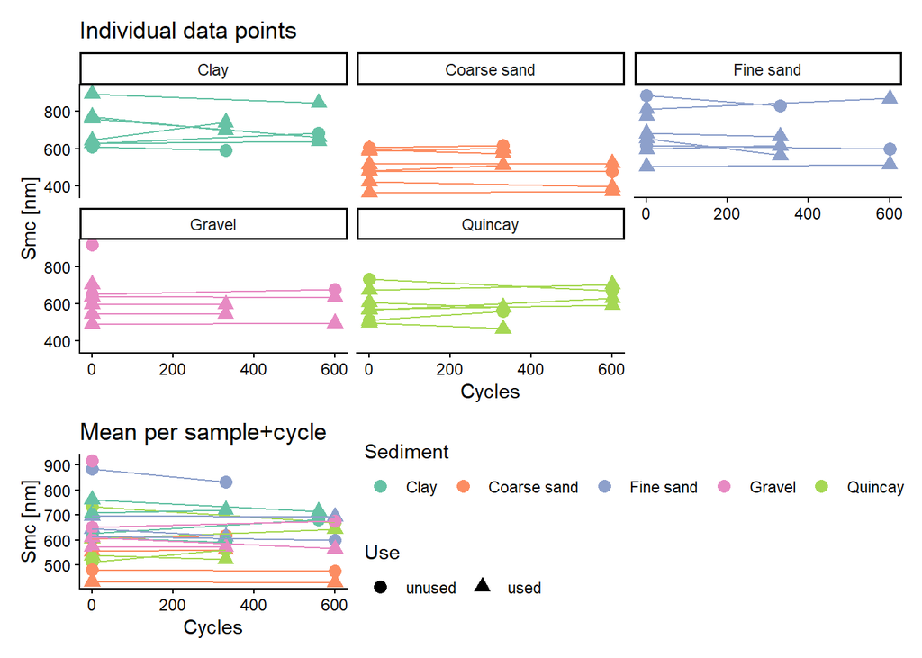

```
$`Sxp [nm]`
```

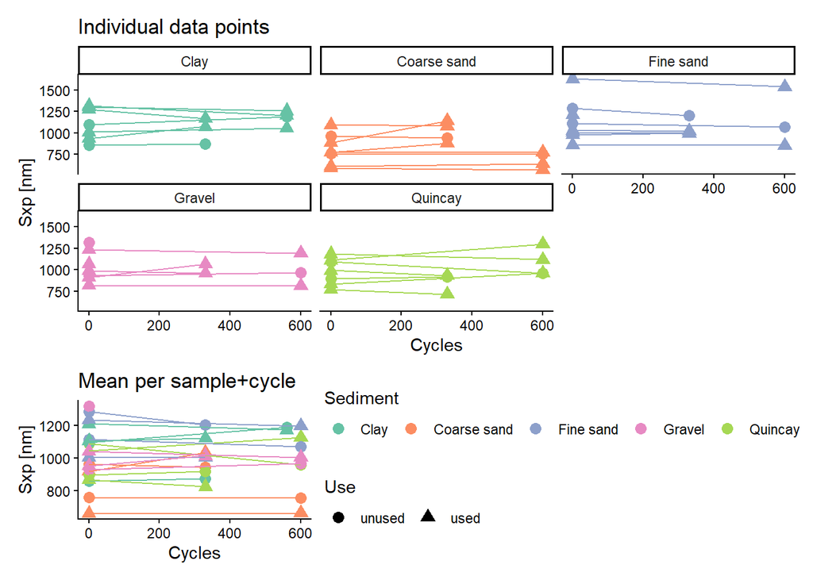

```
$`Sal [µm]`
```

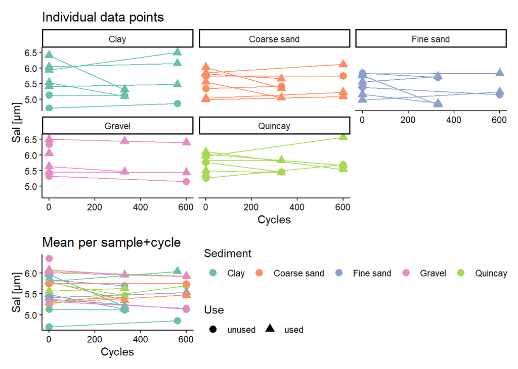

```
$`Str [no unit]`
```

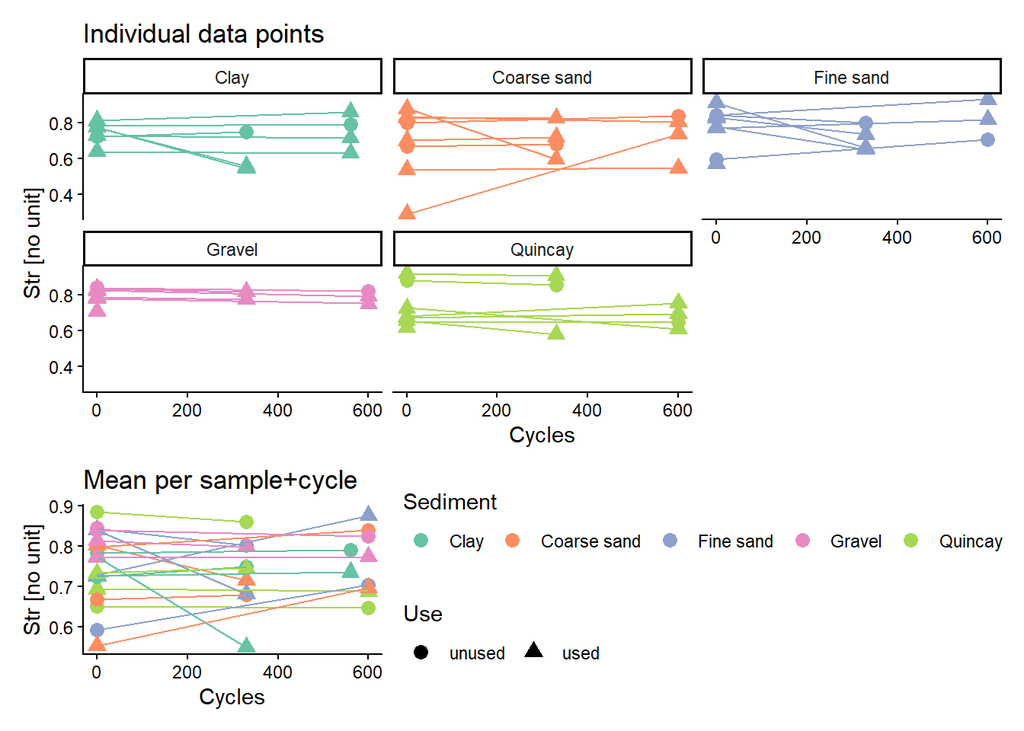

```
$`Std [°]`
```

[22 more figures not shown]

```r
# Design for patchwork combination of plots (see below)
design_patch <- c(area(1, 1, 2, 3), area(3, 1, 3, 1), area(3, 2, 3, 3))

# Plot for every parameters
for (i in names(p_line_NMP17)) {

  # Define y-axis limits based on the range of the y-variable
  # This ensures that both plots have the same y-range
  # Not used currently
  #range_y <- range(FT_NMP17_units[[i]])

  # Plot of individual data points
             #  Define aesthetics
  p_indiv <- ggplot(data = FT_NMP17_units, aes(x = Cycles, y = .data[[i]], color = Sediment, shape = Use)) +

             # Add points
             geom_point(size = 3) +

             # Facet plot by 'Sediment'
             facet_wrap(~ Sediment) +

             # Add lines to connect points with identical "SpecLoc"
             geom_line(linewidth = 0.5, aes(group = SpecLoc), show.legend = FALSE) +

             # Light theme
             theme_classic() +

             # Set2 "may be a problem for some, but not all folks with color vision impairment".
             # However, there is no colorblind safe qualitative set with 5 data classes.
             scale_color_brewer(palette = 'Set2') +

             # Set y-limits
             # Not used currently
             #ylim(range_y[1], range_y[2]) +

             # Add title to plot
             labs(title = "Individual data points") +

             # Position and orientation of legend
             theme(legend.direction = "horizontal", legend.title.position = "top")

  # Plot of means per sample and cycle
  p_mean <- ggplot(data = FT_NMP17_mean, aes(x = Cycles, y = .data[[i]], color = Sediment, shape = Use)) +
            geom_point(size = 3) +
            geom_line(linewidth = 0.5, aes(group = SpecUse), show.legend = FALSE) +
            theme_classic() +
            scale_color_brewer(palette = 'Set2') +
            #ylim(range_y[1], range_y[2]) +
            labs(title = "Mean per sample+cycle") +
            theme(legend.direction = "horizontal", legend.title.position = "top")

  # Combine both plots with patchwork
  p_line_NMP17[[i]] <- p_indiv / p_mean + guide_area() +
                       plot_layout(guides = 'collect', design = design_patch)
}

# Print all plots
print(p_line_NMP17)
```

## 5.3 Save plots

```r
ggsave(filename = "FT_STA-plots_NMP17.pdf", path = dir_plots, plot = p_line_NMP17,
       width = 190, height = 200, units = "mm")
```

# 6 PCA for STA with height maps with <17% NMP

Note that there are too few data points with only height maps <10% NMP to be meaningful for a PCA, so the PCAs are done only with height maps < 17% NMP.

## 6.1 Format data

PCA will be applied to the differences between after and before the experiments, for all surface texture parameter.  
The method below works only with 2 values per group, which is the case here.

### 6.1.1 Define function to calculate difference

```r
# Create function to subtract the 1st value from the 2nd value of a vector
# Returns NA if at least one value is NA
fun_minus <- function(x) {
  x[2] - x[1]
}
```

### 6.1.2 Calculate the difference between after and before

```r
                     # Exclude Cycles
FT_NMP17_pca_data <- select(FT_NMP17, !c(Cycles, NMP_cat)) %>%

                     # Arrange to make sure that the difference is calculated with the correct values
                     # in the correct order
                     arrange(Specimen, Location, State) %>%

                     # Group by Specimen, Sediment and Location (= everything except State)
                     group_by(Specimen, Sediment, Location, Use) %>%

                     # Apply function fun_minus to each group
                     summarize(across(where(is.numeric), fun_minus)) %>%

                     # Remove rows with NA
                     na.omit()
```

## 6.2 Custom plotting function

The library `factoextra` is not maintained anymore so there are some warnings due to issues with newer versions of ggplot2.

```r
custom_pca_biplot <- function(dat, datpca, pc = c(1, 2), geom.pt = "point", col.pt, mean.pt = FALSE,
                              col.pal = brewer.pal(length(unique(datpca[[col.pt]])), "Set2"),
                              pt.size = 3, shape.pt, pt.fill = "white", alph = 1,
                              elli = TRUE, elli.type = "convex", repel.lab = TRUE,
                              col.variable = "black", main.title){

  # Define plotting
  p_out <- fviz_pca_ind(dat, axes = pc,
                           geom.ind = geom.pt, col.ind = datpca[[col.pt]], mean.point = mean.pt,
                           palette = col.pal, pointsize = pt.size, fill.ind = pt.fill, pointshape = 19,
                           addEllipses = elli, ellipse.type = elli.type, alpha = alph,
                           repel = repel.lab, col.var = col.variable, title = main.title, legend.title = "") +
           theme(legend.position = "bottom", legend.box = "vertical") +
           geom_point(aes(shape = datpca[[shape.pt]], color = datpca[[col.pt]]), size = 3) +
           guides(shape = guide_legend(title = shape.pt),
                  color = guide_legend(title = col.pt),
                  fill = "none")

  # Return plotting object
  return(p_out)
}
```

## 6.3 Define columns for colors and shapes

```r
col_PCA <- "Sediment"
shape_PCA <- "Use"
```

## 6.4 Run PCA with all parameters

All STA parameters are used here, except Ssw (column 18), which is almost always 0.  
This PCA is only meant to select the most informative parameters.  
For comments on the code, see section PCA on selected parameters.

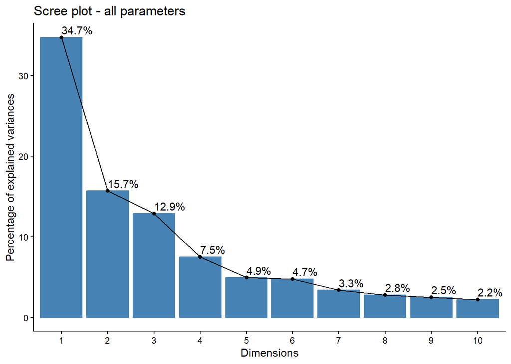

```r
pca_FT_NMP17_all <- prcomp(FT_NMP17_pca_data[c(5:17, 19:38)], scale. = TRUE, center = TRUE)

pca_FT_NMP17_all_scree <- fviz_screeplot(pca_FT_NMP17_all, addlabels = TRUE,
                                         ggtheme = theme_classic(), title = "Scree plot - all parameters")
print(pca_FT_NMP17_all_scree)
```

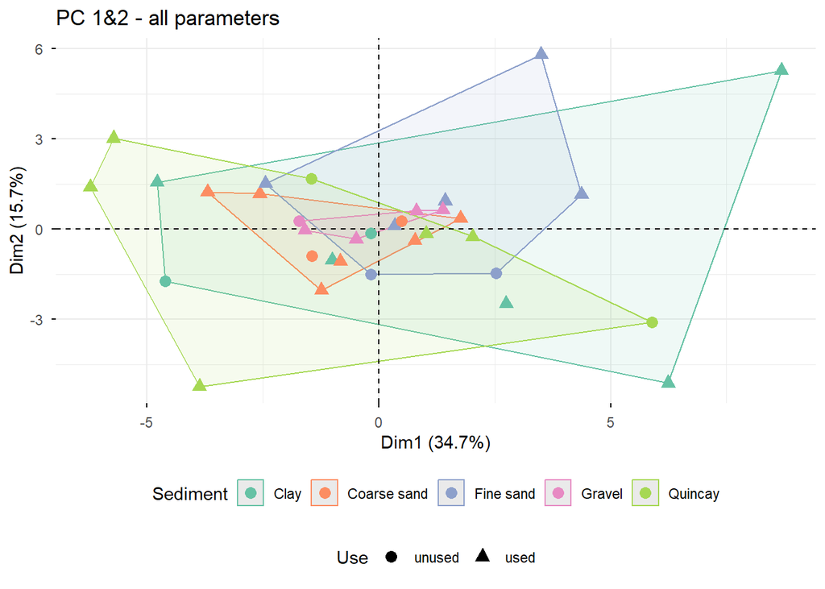

```r
pca_axes12 <- c(1, 2)
plot_title12_all <- paste("PC", paste(pca_axes12, collapse = "&"), "- all parameters")

pca_FT_NMP17_all_ind12 <- custom_pca_biplot(pca_FT_NMP17_all, datpca = FT_NMP17_pca_data, pc = pca_axes12,
                                            col.pt = col_PCA, shape.pt = shape_PCA, alph = 0,
                                            main.title = plot_title12_all)
print(pca_FT_NMP17_all_ind12)
```

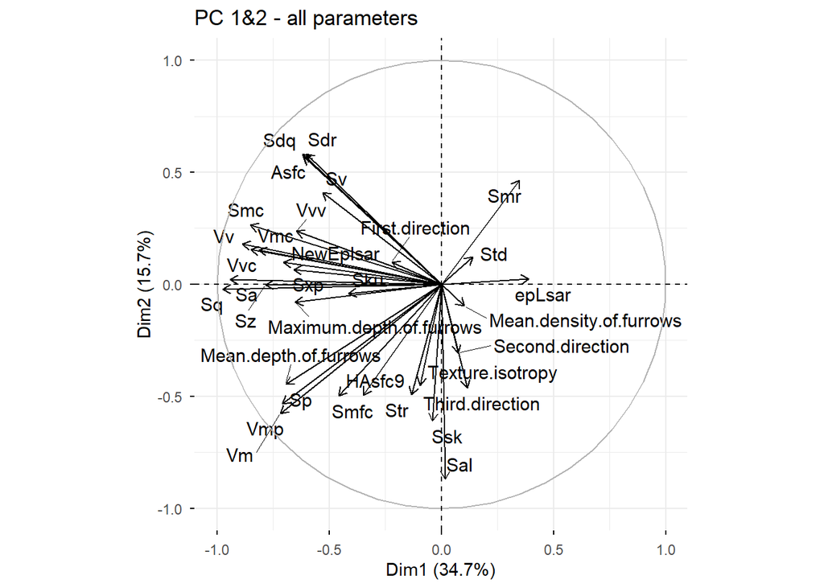

```r
pca_FT_NMP17_all_var12 <- fviz_pca_var(pca_FT_NMP17_all, axes = pca_axes12,
                                       col.var = "black", repel = TRUE, title = plot_title12_all)
print(pca_FT_NMP17_all_var12)
```

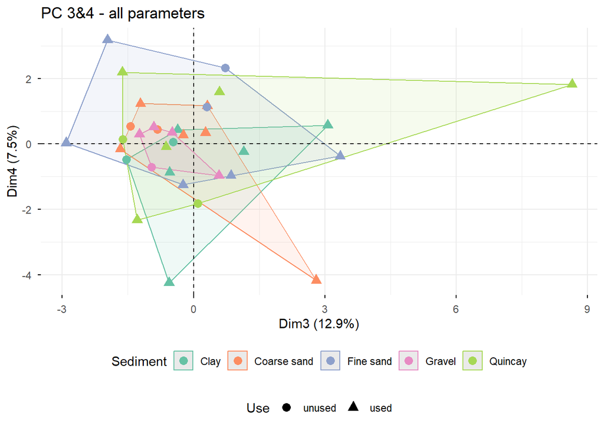

```r
pca_axes34 <- c(3, 4)
plot_title34_all <- paste("PC", paste(pca_axes34, collapse = "&"), "- all parameters")

pca_FT_NMP17_all_ind34 <- custom_pca_biplot(pca_FT_NMP17_all, datpca = FT_NMP17_pca_data, pc = pca_axes34,
                                            col.pt = col_PCA, shape.pt = shape_PCA, alph = 0,
                                            main.title = plot_title34_all)
print(pca_FT_NMP17_all_ind34)
```

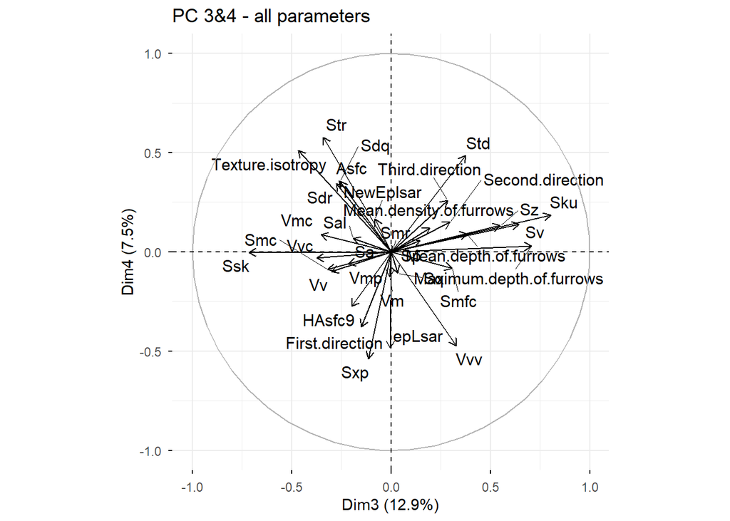

```r
pca_FT_NMP17_all_var34 <- fviz_pca_var(pca_FT_NMP17_all, axes = pca_axes34,
                                       col.var = "black", repel = TRUE, title = plot_title34_all)
print(pca_FT_NMP17_all_var34)
```

```r
all_plots_17_all <- list(pca_FT_NMP17_all_scree,
                         pca_FT_NMP17_all_ind12, pca_FT_NMP17_all_var12,
                         pca_FT_NMP17_all_ind34, pca_FT_NMP17_all_var34)
ggsave(filename = "FT_PCA-plots_NMP17_all-params.pdf", path = dir_plots, plot = all_plots_17_all,
       width = 190, height = 190, units = "mm")
```

## 6.5 PCA on selected parameters

### 6.5.1 Select surface texture parameters

The following parameters are selected for the PCA:

```r
pca_params <- c("Sq", "Ssk", "Sv", "Sxp",
                "Vv", "Vvc", "Vm",
                "Sal", "Str", "epLsar",
                "Mean.density.of.furrows", "Mean.depth.of.furrows", "Maximum.depth.of.furrows",
                "Asfc", "HAsfc9")
cat(paste0(pca_params, "\n"), sep = "")
```

```
Sq
Ssk
Sv
Sxp
Vv
Vvc
Vm
Sal
Str
epLsar
Mean.density.of.furrows
Mean.depth.of.furrows
Maximum.depth.of.furrows
Asfc
HAsfc9
```

### 6.5.2 PCA

```r
pca_FT_NMP17 <- prcomp(FT_NMP17_pca_data[ , pca_params], scale. = TRUE, center = TRUE)
```

### 6.5.3 Plots

#### 6.5.3.1 Scree plot

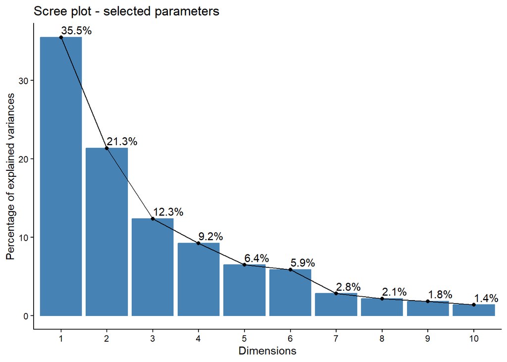

```r
pca_FT_NMP17_scree <- fviz_screeplot(pca_FT_NMP17, addlabels = TRUE,
                                     ggtheme = theme_classic(), title = "Scree plot - selected parameters")
print(pca_FT_NMP17_scree)
```

#### 6.5.3.2 PC1-2

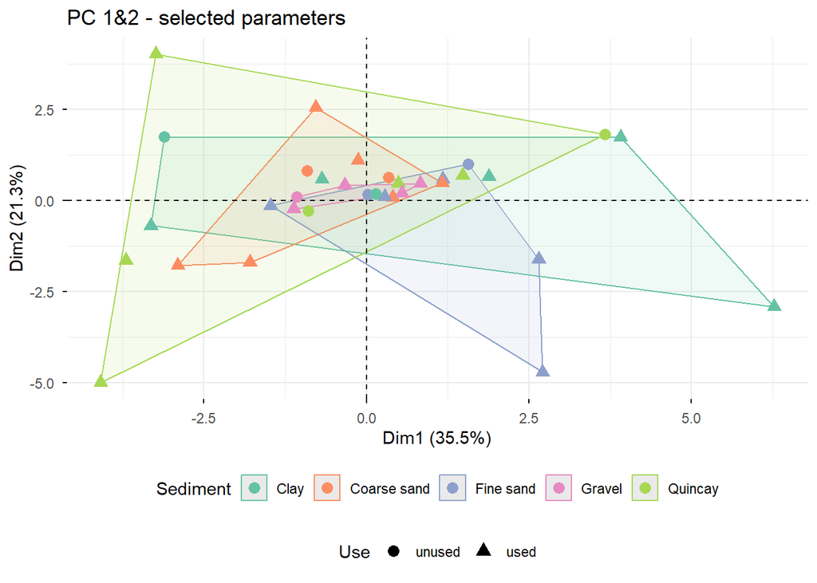

```r
# Plot title
plot_title12 <- paste("PC", paste(pca_axes12, collapse = "&"), "- selected parameters")

# Individual points
pca_FT_NMP17_ind12 <- custom_pca_biplot(pca_FT_NMP17, datpca = FT_NMP17_pca_data, pc = pca_axes12,
                                            col.pt = col_PCA, shape.pt = shape_PCA, alph = 0,
                                            main.title = plot_title12)
print(pca_FT_NMP17_ind12)
```

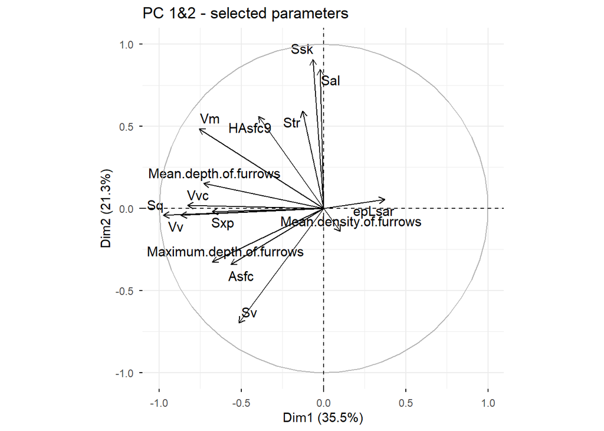

```r
# Contributions of variables
pca_FT_NMP17_var12 <- fviz_pca_var(pca_FT_NMP17, axes = pca_axes12,
                                   col.var = "black", repel = TRUE, title = plot_title12)
print(pca_FT_NMP17_var12)
```

#### 6.5.3.3 PC3-4

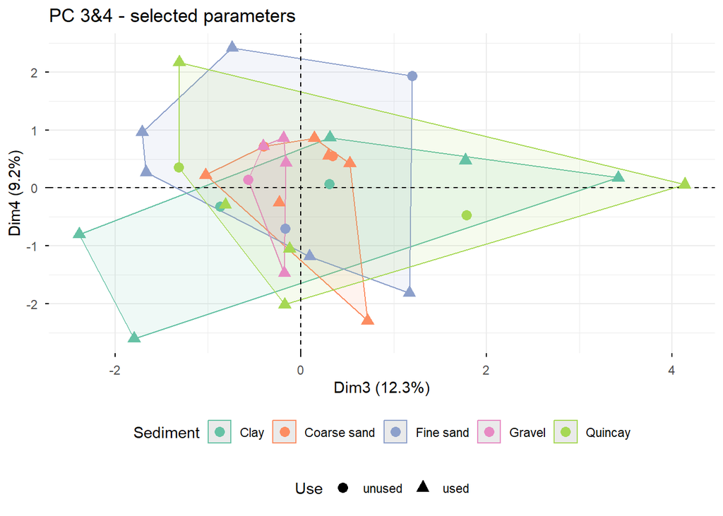

```r
plot_title34 <- paste("PC", paste(pca_axes34, collapse = "&"), "- selected parameters")
pca_FT_NMP17_ind34 <- custom_pca_biplot(pca_FT_NMP17, datpca = FT_NMP17_pca_data, pc = pca_axes34,
                                            col.pt = col_PCA, shape.pt = shape_PCA, alph = 0,
                                            main.title = plot_title34)
print(pca_FT_NMP17_ind34)
```

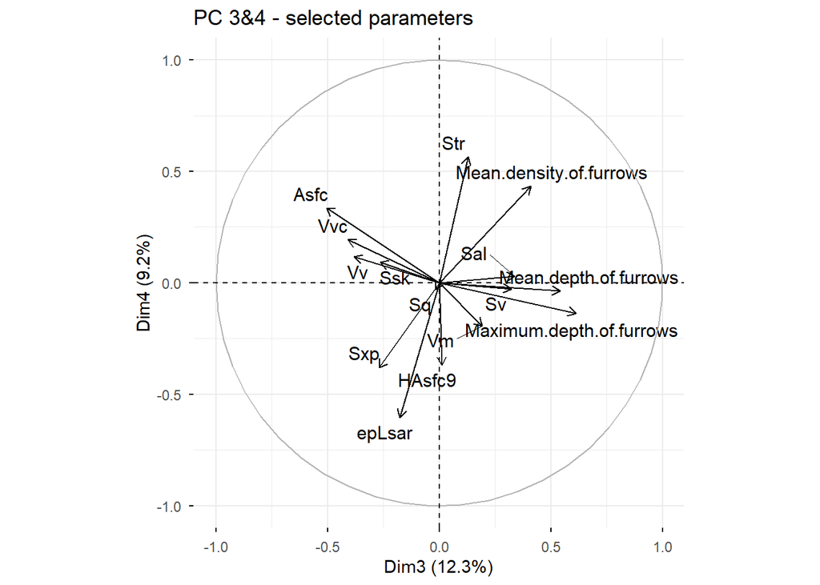

```r
pca_FT_NMP17_var34 <- fviz_pca_var(pca_FT_NMP17, axes = pca_axes34,
                                   col.var = "black", repel = TRUE, title = plot_title34)
print(pca_FT_NMP17_var34)
```

#### 6.5.3.4 Combine plots to save them into 1 file

```r
all_plots_17 <- list(pca_FT_NMP17_scree,
                     pca_FT_NMP17_ind12, pca_FT_NMP17_var12,
                     pca_FT_NMP17_ind34, pca_FT_NMP17_var34)
```

#### 6.5.3.5 Save plots

```r
ggsave(filename = "FT_PCA-plots_NMP17.pdf", path = dir_plots, plot = all_plots_17,
       width = 190, height = 190, units = "mm")
```

# 7 Combined plots with STA-PCA data and movement data

Here, the PCA data for height maps with <17% NMP are combined graphically with movement data.

## 7.1 Read in movement data

```r
mov_file <- list.files(dir_in, pattern = ".*movement.*\\.Rbin$", full.names = TRUE)
mov <- loadObject(mov_file)
```

The following data file has been read: “analysis/derived_data/FT_movement_formatted-data.Rbin”

Below are its structure and first lines:

```r
str(mov)
```

```
'data.frame':   10 obs. of  18 variables:
 $ Specimen                    : chr  "Scra21" "Scra14" "Scra25" "Scra11" ...
 $ Sediment                    : chr  "Clay" "Clay" "Quincay" "Quincay" ...
 $ Freeze.thaw_cycles          : int  330 276 330 600 330 600 330 600 330 600
 $ Original_depth_bottom_point1: int  5 5 5 5 5 5 5 5 5 5
 $ Original_depth_bottom_point2: int  5 5 5 5 5 5 5 5 5 5
 $ Original_depth_top_point1   : num  7 9 7 8 7 8 8 8 8 7.5
 $ Original_depth_top_point2   : num  7 9 7 8 7 8 8 8 8 7.5
 $ Final_depth_top_point1      : num  5.2 10.5 0.5 6 6 9.3 7.8 6 3 5
 $ Final_depth_top_point2      : num  9.9 11.5 6 8 5.6 11.5 9.8 8.5 4.3 10
 $ Movement_point1             : num  -1.8 1.5 -6.5 -2 -1 1.3 -0.2 -2 -5 -2.5
 $ Movement_point2             : num  2.9 2.5 -1 0 -1.4 3.5 1.8 0.5 -3.7 2.5
 $ Abs_movement_point1         : num  1.8 1.5 6.5 2 1 1.3 0.2 2 5 2.5
 $ Abs_movement_point2         : num  2.9 2.5 1 0 1.4 3.5 1.8 0.5 3.7 2.5
 $ Average_movement            : num  0.55 2 -3.75 -1 -1.2 2.4 0.8 -0.75 -4.35 0
 $ Average_movement_CONV       : num  -0.55 -2 3.75 1 1.2 -2.4 -0.8 0.75 4.35 0
 $ Total_abs_movement          : num  4.7 4 7.5 2 2.4 4.8 2 2.5 8.7 5
 $ Lithic_rotation             : chr  "partial" "complete" "partial" "no" ...
 $ Lithic_tilting              : chr  "vertical" "partial" "vertical" "partial" ...
 - attr(*, "comment")= chr "cm"
```

```r
head(mov)
```

```
  Specimen  Sediment Freeze.thaw_cycles Original_depth_bottom_point1
1   Scra21      Clay                330                            5
2   Scra14      Clay                276                            5
3   Scra25   Quincay                330                            5
4   Scra11   Quincay                600                            5
5   Scra17 Fine sand                330                            5
6   Scra16 Fine sand                600                            5
  Original_depth_bottom_point2 Original_depth_top_point1
1                            5                         7
2                            5                         9
3                            5                         7
4                            5                         8
5                            5                         7
6                            5                         8
  Original_depth_top_point2 Final_depth_top_point1 Final_depth_top_point2
```

[output cut: 27 more lines]

## 7.2 PCA with all parameters

For comments on the code, see section PCA with selected parameters.

```r
pca_FT_NMP17_all_scores <- data.frame(FT_NMP17_pca_data[1:4], pca_FT_NMP17_all$x[, c("PC1", "PC2", "PC3", "PC4")])
str(pca_FT_NMP17_all_scores)
```

```
'data.frame':   34 obs. of  8 variables:
 $ Specimen: chr  "Scra11" "Scra11" "Scra11" "Scra11" ...
 $ Sediment: chr  "Quincay" "Quincay" "Quincay" "Quincay" ...
 $ Location: chr  "loc1" "loc2" "loc3" "loc4" ...
 $ Use     : chr  "used" "used" "used" "unused" ...
 $ PC1     : num  -5.72 -3.87 -6.22 5.89 -2.56 ...
 $ PC2     : num  3.02 -5.24 1.39 -3.1 1.18 ...
 $ PC3     : num  -1.6282 -1.2886 8.6479 0.0991 0.2693 ...
 $ PC4     : num  2.188 -2.326 1.822 -1.826 0.347 ...
```

```r
head(pca_FT_NMP17_all_scores)
```

```
  Specimen    Sediment Location    Use        PC1        PC2         PC3
1   Scra11     Quincay     loc1   used -5.7229302  3.0203458 -1.62817807
2   Scra11     Quincay     loc2   used -3.8693078 -5.2440488 -1.28860189
3   Scra11     Quincay     loc3   used -6.2204195  1.3942828  8.64787615
4   Scra11     Quincay     loc4 unused  5.8945530 -3.0952997  0.09907394
5   Scra12 Coarse sand     loc1   used -2.5643253  1.1765376  0.26925064
6   Scra12 Coarse sand     loc2   used  0.7776764 -0.3829512  0.31223296
         PC4
1  2.1881835
2 -2.3257534
3  1.8224988
4 -1.8262992
5  0.3474012
6  1.1673440
```

```r
pca_FT_NMP17_all_scores_used <- filter(pca_FT_NMP17_all_scores, Use == "used")
pca_FT_NMP17_all_scores_sd <- summaryBy(. ~ Specimen + Sediment, data = pca_FT_NMP17_all_scores_used,
                                        FUN = sd) %>%
                              mutate(mean_sd = rowMeans(.[c("PC1.sd", "PC2.sd", "PC3.sd", "PC4.sd")]))
str(pca_FT_NMP17_all_scores_sd)
```

```
'data.frame':   10 obs. of  7 variables:
 $ Specimen: chr  "Scra11" "Scra12" "Scra14" "Scra16" ...
 $ Sediment: chr  "Quincay" "Coarse sand" "Clay" "Fine sand" ...
 $ PC1.sd  : num  1.24 2.33 3.62 2.74 2.12 ...
 $ PC2.sd  : num  4.378 0.916 2.073 0.408 3.035 ...
 $ PC3.sd  : num  5.837 1.45 1.72 0.667 1.842 ...
 $ PC4.sd  : num  2.507 2.876 0.435 2.228 0.448 ...
 $ mean_sd : Named num  3.49 1.89 1.96 1.51 1.86 ...
  ..- attr(*, "names")= chr [1:10] "1" "2" "3" "4" ...
```

```r
head(pca_FT_NMP17_all_scores_sd)
```

```
  Specimen    Sediment   PC1.sd    PC2.sd     PC3.sd    PC4.sd  mean_sd
1   Scra11     Quincay 1.239028 4.3781987 5.83732527 2.5072345 3.490447
2   Scra12 Coarse sand 2.325563 0.9162989 1.44967115 2.8757662 1.891825
3   Scra14        Clay 3.624043 2.0728791 1.71953520 0.4351161 1.962893
4   Scra16   Fine sand 2.741015 0.4081019 0.66703247 2.2281831 1.511083
5   Scra17   Fine sand 2.122170 3.0350240 1.84155705 0.4480647 1.861704
6   Scra21        Clay 9.522061 2.6348814 0.01093741 2.3965758 3.641114
```

```r
pca_all_mov_data <- merge(pca_FT_NMP17_all_scores_sd, mov, by = c("Specimen", "Sediment")) %>%
                    pivot_longer(c(Average_movement_CONV, Total_abs_movement),
                                 names_to = "Parameter", values_to = "Value")

pca_all_mov_data$Parameter <- factor(pca_all_mov_data$Parameter,
                                     levels = c("Average_movement_CONV", "Total_abs_movement"),
                                     labels = c("Average movement [cm]", "Total absolute movement [cm]"))
pca_all_mov_data$Freeze.thaw_cycles <- as.factor(pca_all_mov_data$Freeze.thaw_cycles)

str(pca_all_mov_data)
```

```
tibble [20 × 23] (S3: tbl_df/tbl/data.frame)
 $ Specimen                    : chr [1:20] "Scra11" "Scra11" "Scra12" "Scra12" ...
 $ Sediment                    : chr [1:20] "Quincay" "Quincay" "Coarse sand" "Coarse sand" ...
 $ PC1.sd                      : num [1:20] 1.24 1.24 2.33 2.33 3.62 ...
 $ PC2.sd                      : num [1:20] 4.378 4.378 0.916 0.916 2.073 ...
 $ PC3.sd                      : num [1:20] 5.84 5.84 1.45 1.45 1.72 ...
 $ PC4.sd                      : num [1:20] 2.507 2.507 2.876 2.876 0.435 ...
 $ mean_sd                     : Named num [1:20] 3.49 3.49 1.89 1.89 1.96 ...
  ..- attr(*, "names")= chr [1:20] "1" "1" "2" "2" ...
 $ Freeze.thaw_cycles          : Factor w/ 3 levels "276","330","600": 3 3 2 2 1 1 3 3 2 2 ...
 $ Original_depth_bottom_point1: int [1:20] 5 5 5 5 5 5 5 5 5 5 ...
 $ Original_depth_bottom_point2: int [1:20] 5 5 5 5 5 5 5 5 5 5 ...
 $ Original_depth_top_point1   : num [1:20] 8 8 8 8 9 9 8 8 7 7 ...
 $ Original_depth_top_point2   : num [1:20] 8 8 8 8 9 9 8 8 7 7 ...
 $ Final_depth_top_point1      : num [1:20] 6 6 7.8 7.8 10.5 10.5 9.3 9.3 6 6 ...
 $ Final_depth_top_point2      : num [1:20] 8 8 9.8 9.8 11.5 11.5 11.5 11.5 5.6 5.6 ...
 $ Movement_point1             : num [1:20] -2 -2 -0.2 -0.2 1.5 1.5 1.3 1.3 -1 -1 ...
 $ Movement_point2             : num [1:20] 0 0 1.8 1.8 2.5 2.5 3.5 3.5 -1.4 -1.4 ...
 $ Abs_movement_point1         : num [1:20] 2 2 0.2 0.2 1.5 1.5 1.3 1.3 1 1 ...
 $ Abs_movement_point2         : num [1:20] 0 0 1.8 1.8 2.5 2.5 3.5 3.5 1.4 1.4 ...
 $ Average_movement            : num [1:20] -1 -1 0.8 0.8 2 2 2.4 2.4 -1.2 -1.2 ...
 $ Lithic_rotation             : chr [1:20] "no" "no" "partial" "partial" ...
 $ Lithic_tilting              : chr [1:20] "partial" "partial" "partial" "partial" ...
 $ Parameter                   : Factor w/ 2 levels "Average movement [cm]",..: 1 2 1 2 1 2 1 2 1 2 ...
 $ Value                       : num [1:20] 1 2 -0.8 2 -2 4 -2.4 4.8 1.2 2.4 ...
```

```r
head(pca_all_mov_data)
```

```
# A tibble: 6 × 23
  Specimen Sediment    PC1.sd PC2.sd PC3.sd PC4.sd mean_sd Freeze.thaw_cycles
  <chr>    <chr>        <dbl>  <dbl>  <dbl>  <dbl>   <dbl> <fct>
1 Scra11   Quincay       1.24  4.38    5.84  2.51     3.49 600
2 Scra11   Quincay       1.24  4.38    5.84  2.51     3.49 600
3 Scra12   Coarse sand   2.33  0.916   1.45  2.88     1.89 330
4 Scra12   Coarse sand   2.33  0.916   1.45  2.88     1.89 330
5 Scra14   Clay          3.62  2.07    1.72  0.435    1.96 276
6 Scra14   Clay          3.62  2.07    1.72  0.435    1.96 276
# ℹ 15 more variables: Original_depth_bottom_point1 <int>,
#   Original_depth_bottom_point2 <int>, Original_depth_top_point1 <dbl>,
#   Original_depth_top_point2 <dbl>, Final_depth_top_point1 <dbl>,
#   Final_depth_top_point2 <dbl>, Movement_point1 <dbl>, Movement_point2 <dbl>,
#   Abs_movement_point1 <dbl>, Abs_movement_point2 <dbl>,
#   Average_movement <dbl>, Lithic_rotation <chr>, Lithic_tilting <chr>,
#   Parameter <fct>, Value <dbl>
```

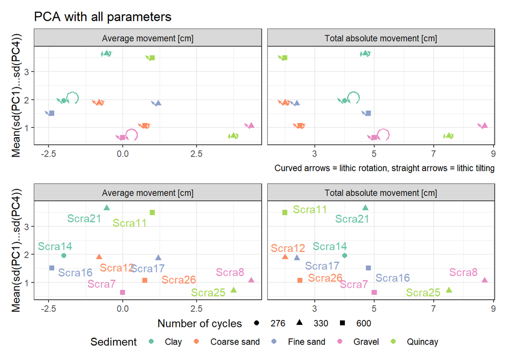

```r
pca_all_mov <- ggplot(data = pca_all_mov_data,
                      aes(x = Value, y = mean_sd, color = Sediment, shape = Freeze.thaw_cycles)) +
               facet_wrap(~ Parameter, scales = "free_x") +
               geom_point(size = 2) +
               geom_arrow_curve(data = pca_all_mov_data[pca_all_mov_data$Lithic_rotation == "complete", ],
                                aes(x = Value + 0.4, xend = Value + 0.2,
                                    y = mean_sd - 0.1, yend = mean_sd - 0.1),
                                curvature = 4, length_head = 3, linewidth = 0.5, show.legend = FALSE) +
               geom_arrow_curve(data = pca_all_mov_data[pca_all_mov_data$Lithic_rotation == "partial", ],
                                aes(x = Value + 0.05, xend = Value + 0.05,
                                    y = mean_sd - 0.1, yend = mean_sd + 0.1),
                                curvature = 1, length_head = 3, linewidth = 0.5, show.legend = FALSE) +
               geom_arrow_curve(data = pca_all_mov_data[pca_all_mov_data$Lithic_tilting == "vertical", ],
                                aes(x = Value - 0.15, xend = Value - 0.15,
                                    y = mean_sd - 0.1, yend = mean_sd + 0.1),
                                curvature = 0, length_head = 3, linewidth = 0.5, show.legend = FALSE) +
               geom_arrow_curve(data = pca_all_mov_data[pca_all_mov_data$Lithic_tilting == "partial", ],
                                aes(x = Value - 0.05, xend = Value - 0.25,
                                    y = mean_sd - 0.1, yend = mean_sd + 0.1),
                                curvature = 0, length_head = 3, linewidth = 0.5, show.legend = FALSE) +
               theme_bw() +
               scale_color_brewer(palette = 'Set2') +
               labs(x = NULL, y = "Mean(sd(PC1)...sd(PC4))",
                    title = "PCA with all parameters",
                    caption = "Curved arrows = lithic rotation, straight arrows = lithic tilting",
                    shape = "Number of cycles")

plot_xlims_all <- list(scale_x_continuous(limits = layer_scales(pca_all_mov, 1, 1)$x$range$range),
                  scale_x_continuous(limits = layer_scales(pca_all_mov, 1, 2)$x$range$range))
plot_ylims_all <- list(scale_y_continuous(limits = layer_scales(pca_all_mov, 1, 1)$y$range$range),
                  scale_y_continuous(limits = layer_scales(pca_all_mov, 1, 2)$y$range$range))

pca_mov_all_ID <- ggplot(data = pca_all_mov_data,
                         aes(x = Value, y = mean_sd, color = Sediment, shape = Freeze.thaw_cycles)) +
                  facet_wrap(~ Parameter, scales = "free_x") +
                  geom_point(size = 2) +
                  theme_bw() +
                  scale_color_brewer(palette = 'Set2') +
                  labs(x = NULL, y = "Mean(sd(PC1)...sd(PC4))",
                       shape = "Number of cycles") +
                  facetted_pos_scales(x = plot_xlims_all, y = plot_ylims_all) +
                  geom_text_repel(aes(label = Specimen), point.padding = 4, show.legend = FALSE)
pca_mov_all_patch <- pca_all_mov / pca_mov_all_ID + plot_layout(guides = 'collect') &
                     theme(legend.position = 'bottom', legend.box = "vertical", legend.margin = margin(t = -10))

print(pca_mov_all_patch)
```

```r
ggsave(filename = "FT_PCA-mov-plot_NMP17_all-params.pdf", path = dir_plots, plot = pca_mov_all_patch,
       width = 190, height = 200, units = "mm")
```

## 7.3 PCA with selected parameters

### 7.3.1 Extract PC scores on PC1 to PC4

```r
pca_FT_NMP17_scores <- data.frame(FT_NMP17_pca_data[1:4], pca_FT_NMP17$x[, c("PC1", "PC2", "PC3", "PC4")])
```

Below are the structure and first lines of the PC scores:

```r
str(pca_FT_NMP17_scores)
```

```
'data.frame':   34 obs. of  8 variables:
 $ Specimen: chr  "Scra11" "Scra11" "Scra11" "Scra11" ...
 $ Sediment: chr  "Quincay" "Quincay" "Quincay" "Quincay" ...
 $ Location: chr  "loc1" "loc2" "loc3" "loc4" ...
 $ Use     : chr  "used" "used" "used" "unused" ...
 $ PC1     : num  -3.7 -3.24 -4.09 3.67 -1.79 ...
 $ PC2     : num  -1.64 4.03 -5 1.81 -1.69 ...
 $ PC3     : num  -1.308 -0.174 4.135 1.783 0.299 ...
 $ PC4     : num  2.1702 -2.013 0.0584 -0.4686 0.554 ...
```

```r
head(pca_FT_NMP17_scores)
```

```
  Specimen    Sediment Location    Use        PC1         PC2        PC3
1   Scra11     Quincay     loc1   used -3.7016556 -1.64049159 -1.3081859
2   Scra11     Quincay     loc2   used -3.2375559  4.02584485 -0.1744678
3   Scra11     Quincay     loc3   used -4.0896542 -5.00229280  4.1352554
4   Scra11     Quincay     loc4 unused  3.6696420  1.81370039  1.7825208
5   Scra12 Coarse sand     loc1   used -1.7929242 -1.69195870  0.2986382
6   Scra12 Coarse sand     loc2   used  0.4031036  0.09010813  0.5272444
          PC4
1  2.17021415
2 -2.01301223
3  0.05840911
4 -0.46858267
5  0.55395403
6  0.42200060
```

### 7.3.2 Calculate variability of PC scores per specimen and sediment, using only used surfaces

```r
# keep only used surfaces
pca_FT_NMP17_scores_used <- filter(pca_FT_NMP17_scores, Use == "used")

                          # SD for each PC per specimen and sediment
pca_FT_NMP17_scores_sd <- summaryBy(. ~ Specimen + Sediment, data = pca_FT_NMP17_scores_used,
                                    FUN = sd) %>%

                          # mean of both SDs per specimen and sediment
                          mutate(mean_sd = rowMeans(.[c("PC1.sd", "PC2.sd", "PC3.sd", "PC4.sd")]))

# Check output
str(pca_FT_NMP17_scores_sd)
```

```
'data.frame':   10 obs. of  7 variables:
 $ Specimen: chr  "Scra11" "Scra12" "Scra14" "Scra16" ...
 $ Sediment: chr  "Quincay" "Coarse sand" "Clay" "Fine sand" ...
 $ PC1.sd  : num  0.427 1.682 2.302 1.875 1.386 ...
 $ PC2.sd  : num  4.563 1.055 0.642 0.515 2.439 ...
 $ PC3.sd  : num  2.872 0.211 1.554 0.685 1.431 ...
 $ PC4.sd  : num  2.092 1.606 0.347 1.033 1.07 ...
 $ mean_sd : Named num  2.49 1.14 1.21 1.03 1.58 ...
  ..- attr(*, "names")= chr [1:10] "1" "2" "3" "4" ...
```

```r
head(pca_FT_NMP17_scores_sd)
```

```
  Specimen    Sediment    PC1.sd    PC2.sd    PC3.sd    PC4.sd  mean_sd
1   Scra11     Quincay 0.4266151 4.5628271 2.8719936 2.0916457 2.488270
2   Scra12 Coarse sand 1.6819205 1.0551604 0.2106412 1.6060142 1.138434
3   Scra14        Clay 2.3023622 0.6417929 1.5542512 0.3468721 1.211320
4   Scra16   Fine sand 1.8749613 0.5149663 0.6854697 1.0326378 1.027009
5   Scra17   Fine sand 1.3863409 2.4392036 1.4314066 1.0697063 1.581664
6   Scra21        Clay 6.7823910 1.5710046 0.4178064 1.2734679 2.511167
```

### 7.3.3 Combine data

```r
                # Merge together
pca_mov_data <- merge(pca_FT_NMP17_scores_sd, mov, by = c("Specimen", "Sediment")) %>%

                # Pivot to longer format for facetting
                pivot_longer(c(Average_movement_CONV, Total_abs_movement),
                             names_to = "Parameter", values_to = "Value")

# Convert to factor for facet labels
pca_mov_data$Parameter <- factor(pca_mov_data$Parameter,
                                 levels = c("Average_movement_CONV", "Total_abs_movement"),
                                 labels = c("Average movement [cm]", "Total absolute movement [cm]"))

# Convert to factor for shapes
pca_mov_data$Freeze.thaw_cycles <- as.factor(pca_mov_data$Freeze.thaw_cycles)

# Check output
str(pca_mov_data)
```

```
tibble [20 × 23] (S3: tbl_df/tbl/data.frame)
 $ Specimen                    : chr [1:20] "Scra11" "Scra11" "Scra12" "Scra12" ...
 $ Sediment                    : chr [1:20] "Quincay" "Quincay" "Coarse sand" "Coarse sand" ...
 $ PC1.sd                      : num [1:20] 0.427 0.427 1.682 1.682 2.302 ...
 $ PC2.sd                      : num [1:20] 4.563 4.563 1.055 1.055 0.642 ...
 $ PC3.sd                      : num [1:20] 2.872 2.872 0.211 0.211 1.554 ...
 $ PC4.sd                      : num [1:20] 2.092 2.092 1.606 1.606 0.347 ...
 $ mean_sd                     : Named num [1:20] 2.49 2.49 1.14 1.14 1.21 ...
  ..- attr(*, "names")= chr [1:20] "1" "1" "2" "2" ...
 $ Freeze.thaw_cycles          : Factor w/ 3 levels "276","330","600": 3 3 2 2 1 1 3 3 2 2 ...
 $ Original_depth_bottom_point1: int [1:20] 5 5 5 5 5 5 5 5 5 5 ...
 $ Original_depth_bottom_point2: int [1:20] 5 5 5 5 5 5 5 5 5 5 ...
 $ Original_depth_top_point1   : num [1:20] 8 8 8 8 9 9 8 8 7 7 ...
 $ Original_depth_top_point2   : num [1:20] 8 8 8 8 9 9 8 8 7 7 ...
 $ Final_depth_top_point1      : num [1:20] 6 6 7.8 7.8 10.5 10.5 9.3 9.3 6 6 ...
 $ Final_depth_top_point2      : num [1:20] 8 8 9.8 9.8 11.5 11.5 11.5 11.5 5.6 5.6 ...
 $ Movement_point1             : num [1:20] -2 -2 -0.2 -0.2 1.5 1.5 1.3 1.3 -1 -1 ...
 $ Movement_point2             : num [1:20] 0 0 1.8 1.8 2.5 2.5 3.5 3.5 -1.4 -1.4 ...
 $ Abs_movement_point1         : num [1:20] 2 2 0.2 0.2 1.5 1.5 1.3 1.3 1 1 ...
 $ Abs_movement_point2         : num [1:20] 0 0 1.8 1.8 2.5 2.5 3.5 3.5 1.4 1.4 ...
 $ Average_movement            : num [1:20] -1 -1 0.8 0.8 2 2 2.4 2.4 -1.2 -1.2 ...
 $ Lithic_rotation             : chr [1:20] "no" "no" "partial" "partial" ...
 $ Lithic_tilting              : chr [1:20] "partial" "partial" "partial" "partial" ...
 $ Parameter                   : Factor w/ 2 levels "Average movement [cm]",..: 1 2 1 2 1 2 1 2 1 2 ...
 $ Value                       : num [1:20] 1 2 -0.8 2 -2 4 -2.4 4.8 1.2 2.4 ...
```

```r
head(pca_mov_data)
```

```
# A tibble: 6 × 23
  Specimen Sediment    PC1.sd PC2.sd PC3.sd PC4.sd mean_sd Freeze.thaw_cycles
  <chr>    <chr>        <dbl>  <dbl>  <dbl>  <dbl>   <dbl> <fct>
1 Scra11   Quincay      0.427  4.56   2.87   2.09     2.49 600
2 Scra11   Quincay      0.427  4.56   2.87   2.09     2.49 600
3 Scra12   Coarse sand  1.68   1.06   0.211  1.61     1.14 330
4 Scra12   Coarse sand  1.68   1.06   0.211  1.61     1.14 330
5 Scra14   Clay         2.30   0.642  1.55   0.347    1.21 276
6 Scra14   Clay         2.30   0.642  1.55   0.347    1.21 276
# ℹ 15 more variables: Original_depth_bottom_point1 <int>,
#   Original_depth_bottom_point2 <int>, Original_depth_top_point1 <dbl>,
#   Original_depth_top_point2 <dbl>, Final_depth_top_point1 <dbl>,
#   Final_depth_top_point2 <dbl>, Movement_point1 <dbl>, Movement_point2 <dbl>,
#   Abs_movement_point1 <dbl>, Abs_movement_point2 <dbl>,
#   Average_movement <dbl>, Lithic_rotation <chr>, Lithic_tilting <chr>,
#   Parameter <fct>, Value <dbl>
```

### 7.3.4 Combined plots

#### 7.3.4.1 Plots showing lithic rotation and tilt

```r
           # Define data and aes for points
pca_mov <- ggplot(data = pca_mov_data,
                  aes(x = Value, y = mean_sd, color = Sediment, shape = Freeze.thaw_cycles)) +

           # Facetting
           facet_wrap(~ Parameter, scales = "free_x") +

           # Add points
           geom_point(size = 2) +

           # Add 360° curved arrows for complete rotation
                            # Subset dataset
           geom_arrow_curve(data = pca_mov_data[pca_mov_data$Lithic_rotation == "complete", ],

                            # New aes for beginning and end of arrows
                            aes(x = Value + 0.4, xend = Value + 0.2,
                                y = mean_sd - 0.1, yend = mean_sd - 0.1),

                            # Other settings
                            curvature = 4, length_head = 3, linewidth = 0.5, show.legend = FALSE) +

           # Add 180° curved arrows for partial rotation
           geom_arrow_curve(data = pca_mov_data[pca_mov_data$Lithic_rotation == "partial", ],
                            aes(x = Value + 0.05, xend = Value + 0.05,
                                y = mean_sd - 0.1, yend = mean_sd + 0.1),
                            curvature = 1, length_head = 3, linewidth = 0.5, show.legend = FALSE) +

           # Add vertical straight arrows for vertical tilting
           geom_arrow_curve(data = pca_mov_data[pca_mov_data$Lithic_tilting == "vertical", ],
                            aes(x = Value - 0.15, xend = Value - 0.15,
                                y = mean_sd - 0.1, yend = mean_sd + 0.1),
                            curvature = 0, length_head = 3, linewidth = 0.5, show.legend = FALSE) +

           # Add oblique straight arrows for partial tilting
           geom_arrow_curve(data = pca_mov_data[pca_mov_data$Lithic_tilting == "partial", ],
                            aes(x = Value - 0.05, xend = Value - 0.25,
                                y = mean_sd - 0.1, yend = mean_sd + 0.1),
                            curvature = 0, length_head = 3, linewidth = 0.5, show.legend = FALSE) +

           # Other settings (see above)
           theme_bw() +
           scale_color_brewer(palette = 'Set2') +

           # Adjust X and Y labels and add caption
           labs(x = NULL, y = "Mean(sd(PC1)...sd(PC4))",
                title = "PCA with selected parameters",
                caption = "Curved arrows = lithic rotation, straight arrows = lithic tilting",
                shape = "Number of cycles")
```

#### 7.3.4.2 Plots identifying specimens

Same plot as before, but without arrows showing lithic rotation and tilt, and with specimen identified.

```r
# Define x and y limits based on previous plot
plot_xlims <- list(scale_x_continuous(limits = layer_scales(pca_mov, 1, 1)$x$range$range),
                   scale_x_continuous(limits = layer_scales(pca_mov, 1, 2)$x$range$range))
plot_ylims <- list(scale_y_continuous(limits = layer_scales(pca_mov, 1, 1)$y$range$range),
                   scale_y_continuous(limits = layer_scales(pca_mov, 1, 2)$y$range$range))

# Plot
pca_mov_ID <- ggplot(data = pca_mov_data,
                     aes(x = Value, y = mean_sd, color = Sediment, shape = Freeze.thaw_cycles)) +
              facet_wrap(~ Parameter, scales = "free_x") +
              geom_point(size = 2) +
              theme_bw() +
              scale_color_brewer(palette = 'Set2') +
              labs(x = NULL, y = "Mean(sd(PC1)...sd(PC4))",
                   shape = "Number of cycles") +

              # Set x-limits
              # warning on y-scale can be ignored
              facetted_pos_scales(x = plot_xlims, y = plot_ylims) +

              # Identify points
              geom_text_repel(aes(label = Specimen), point.padding = 4, show.legend = FALSE)
```

### 7.3.5 Patch plots together and print

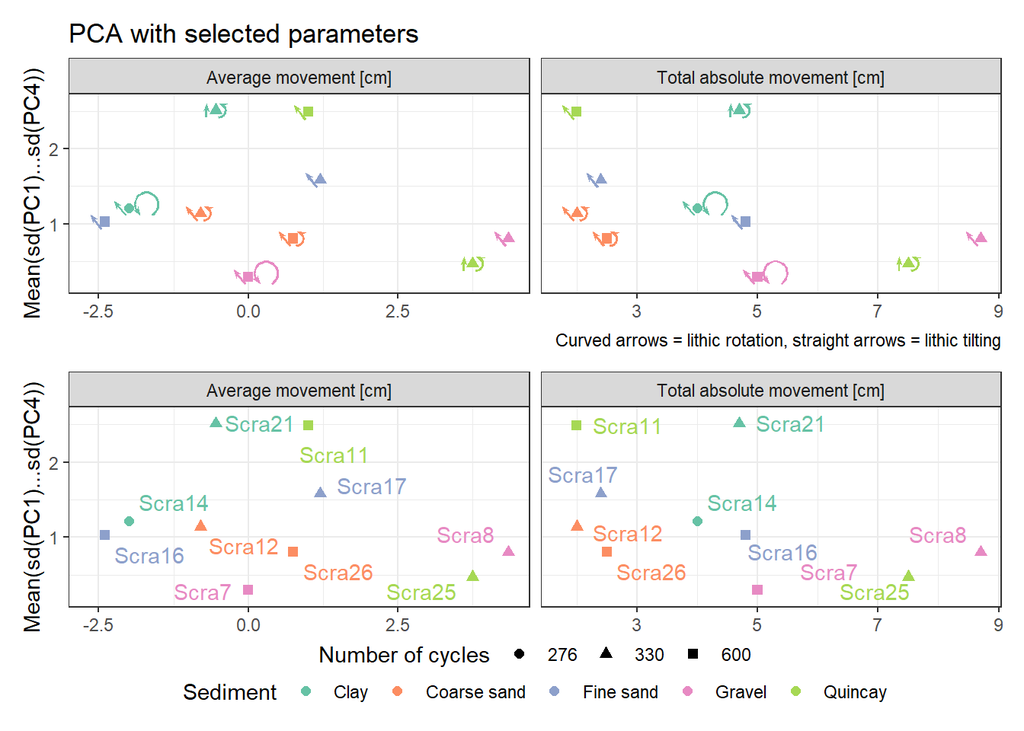

```r
pca_mov_patch <- pca_mov / pca_mov_ID + plot_layout(guides = 'collect') &

                 # legend.margin reduces the space between the plot and the legends
                 theme(legend.position = 'bottom', legend.box = "vertical", legend.margin = margin(t = -10))

print(pca_mov_patch)
```

### 7.3.6 Save to PDF

```r
ggsave(filename = "FT_PCA-mov-plot_NMP17.pdf", path = dir_plots, plot = pca_mov_patch,
       width = 190, height = 200, units = "mm")
```

# 8 Line plots for STA with height maps with <10% NMP

For comments on the code, see section Line plots for height maps with <17% NMP.